# setup-after-installing-python

## Using Python in RStudio

### Mac & Linux users

You can now use RStudio as an effective Python IDE. To do so, follow these steps after installing miniconda:

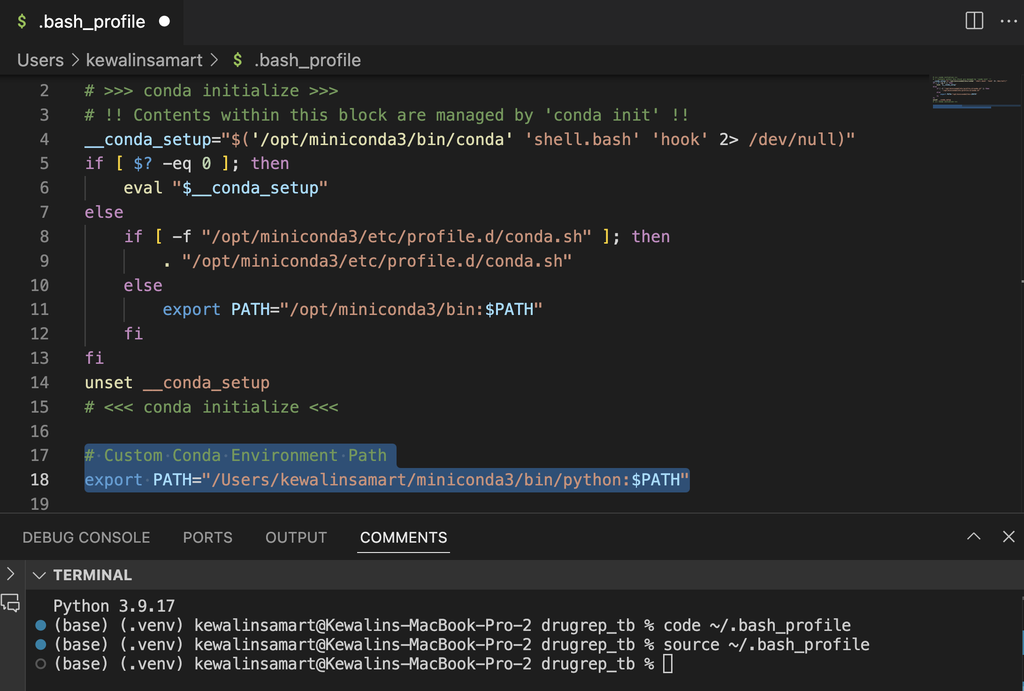

!! If you’re encountering the error `zsh: command not found`: code when trying to use the code command for Visual Studio Code, follow these steps to resolve it:

- Step 1: Verify VS Code Installation to make sure Visual Studio Code is installed on your system.
  - Download and install it from [VS Code’s website](https://code.visualstudio.com/).
  - Open VS Code to confirm it is installed correctly.
- Step 2: Install the code Command in PATH
  - Open Visual Studio Code.
  - Access the Command Palett`e:
    - On Mac: `Cmd + Shift + P`
    - On Windows/Linux: `Ctrl + Shift + P`
  - Type: `Shell Command: Install 'code' command in PATH`
  - Select the option. You should see a success message.
6. **Restart R!**
7. Start using Python in RStudio by typing `reticulate::repl_python()` in the R console, or running a line of Python code from a Python script from the RStudio editor by Cntrl + enter. Or by running scripts from the terminal inside RStudio.

[figure not shown]

### Windows users

1. Install the {reticulate} package: `install.packages("reticulate")`
2. Install the {png} package (a dependency of reticulate that is not well managed yet): `install.packages("png")`
3. Find your path to miniconda by typing `which python` in a terminal (Git Bash on Windows) outside of RStudio
4. Specify that {reticulate} should use the miniconda version of Python in your `.Rprofile` file:
- type `usethis::edit_r_profile()` into the R console inside RStudio, and an `.Rprofile` file from your HOME directory should open in RStudio
- add this to your `.Rprofile` file: `Sys.setenv(RETICULATE_PYTHON = "path_to_miniconda's_python")` replacing `"path_to_miniconda's_python"` with the path to your miniconda Python. In Windows, you need `\\` instead of a `\` to separate the directories, for example my path here would be: `C:\\Users\\tiffany.timbers\\miniconda3\\python.exe`.
5. Open Global Options in RStudio and in the Terminal sub-menu, select “Custom” as the “New terminals to open with” option, and add the path to GitBash (should be something like `C:/Program Files/Git/bin/bash.exe`) as the “Custom shell binary” option. Finally set `-l` (lower case L) as the option for “Custom shell command-line options”.

[figure not shown]

6. **Restart R!** Open R and close the terminal tab. Open a new terminal.

[figure not shown]

7. Start using Python in RStudio by typing `reticulate::repl_python()` in the R console, or running a line of Python code from a Python script from the RStudio editor by Cntrl + enter. Or by running scripts from the terminal inside RStudio.